# Лабораторная работа №3

Основы информационной безопасности

Мурашов И. В., НКАбд-03-23

Российский университет дружбы народов, Москва, Россия

22 марта 2025

## Докладчик

- Мурашов Иван Вячеславович
- Cтудент, 2 курс, группа НКАбд-03-23
- Российский университет дружбы народов
- 1132236018@rudn.ru
- https://neve7mind.github.io

## Цель работы

Целью данной работы является приобретение практических навыков работы в консоли с атрибутами файлов для групп пользователей.

## Выполнение лабораторной работы

1. Создаю пользователя guest2 с помощью комманды `useradd` и задаю ему пароль `passwd` (пользователь guest был создан во время выполнения 2ой лабораторной работы.

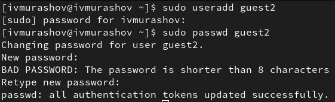

Добавление пользователя

## Выполнение лабораторной работы

2. Добавляю пользователя guest2 в группу guest.

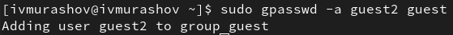

Добавление пользователя

## Выполнение лабораторной работы

3. Захожу в guest и guest2 в консоли с помощью команды `su <имя пользователся>`.

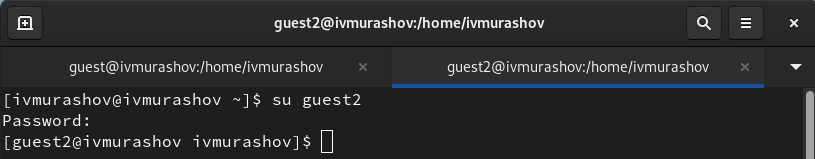

Вход через аккаунт пользователя

## Выполнение лабораторной работы

4. Просматриваю путь директории, где я нахожусь на обоих аккаунтах.

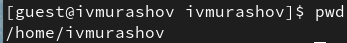

Текущая директория

## Выполнение лабораторной работы

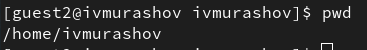

Текущая директория

## Выполнение лабораторной работы

5. Проверяю имя пользователя с помощью команды `whoami`, далее с помощью команды `id` просматриваю группы, к которым принадлежит пользователь, коды этих групп (`gid`), команда `groups` выводит список групп, в которые входит пользователь.

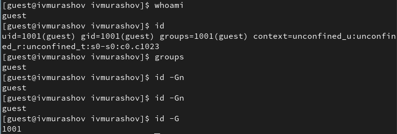

Информация о пользователе

## Выполнение лабораторной работы

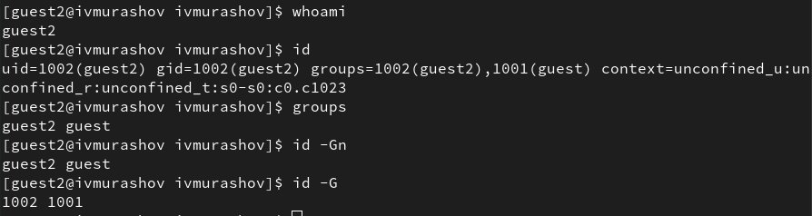

Информация о пользователе

## Выполнение лабораторной работы

6. Получаю информацию о пользователях с помощью команды

```
cat /etc/group | grep 'guest'
```

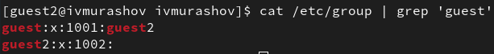

Просмотр файла group

## Выполнение лабораторной работы

7. С помощью `newgrp` регистрирую нового пользователя в группе guest.

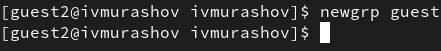

Регистрация нового пользователя

## Выполнение лабораторной работы

8. Добавляю права rwx группе пользователей guest.

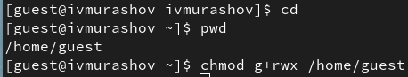

## Выполнение лабораторной работы

9. Снимаю атрибуты командой chmod 000 dir1, при проверке с помощью команды ls -l видно, что теперь атрибуты действительно сняты.

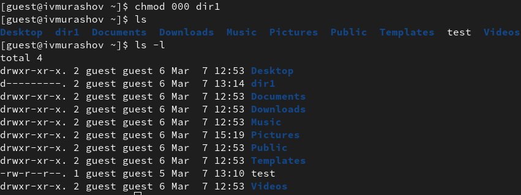

Снятие атрибутов с директории

## Выполнение лабораторной работы

## Заполнение таблицы 3.1

Проверяю, как guest2 взаимодействует с файлами директории dir1.

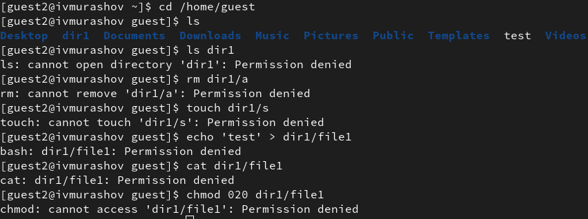

Пример заполнения таблицы 3.1

## Заполнение таблицы 3.1

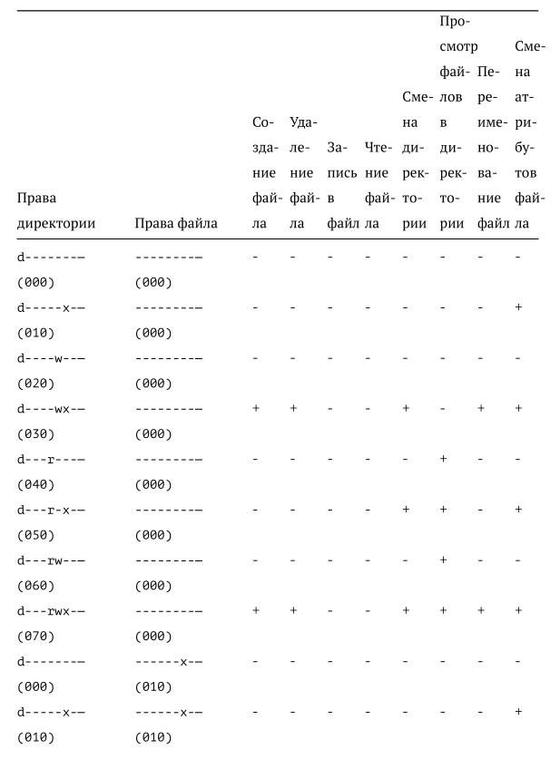

Таблица 3.1

## Заполнение таблицы 3.1

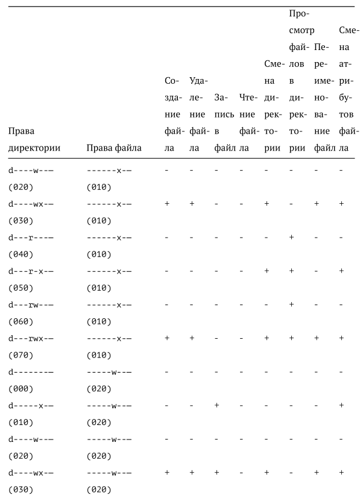

Таблица 3.1

## Заполнение таблицы 3.1

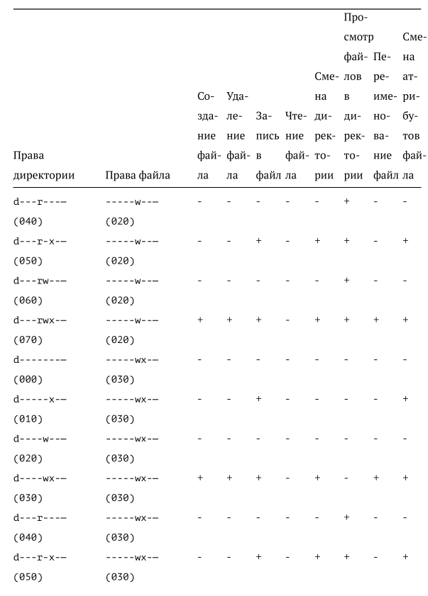

Таблица 3.1

## Заполнение таблицы 3.1

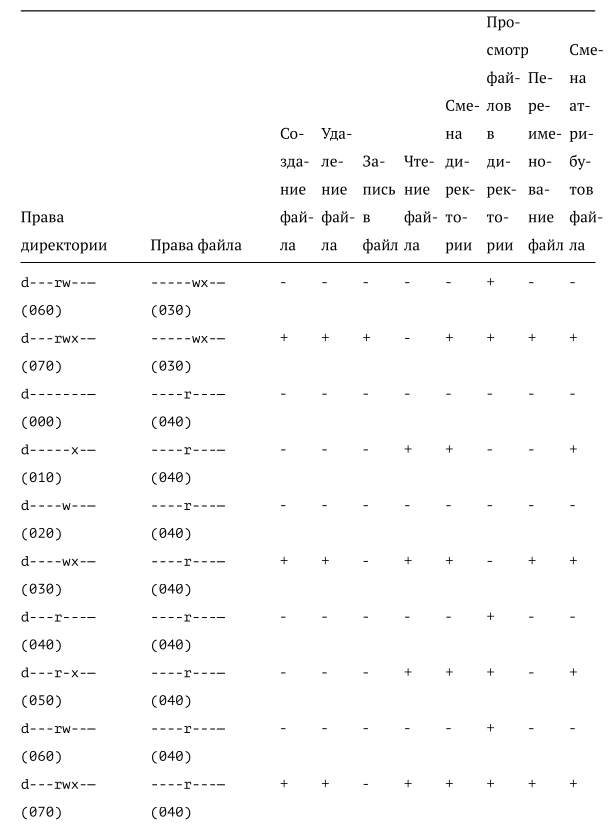

Таблица 3.1

## Заполнение таблицы 3.1

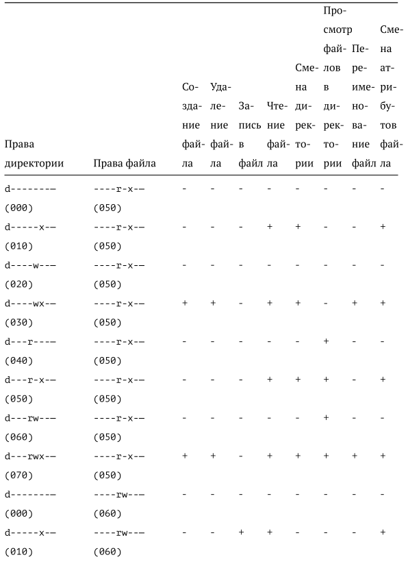

Таблица 3.1

## Заполнение таблицы 3.1

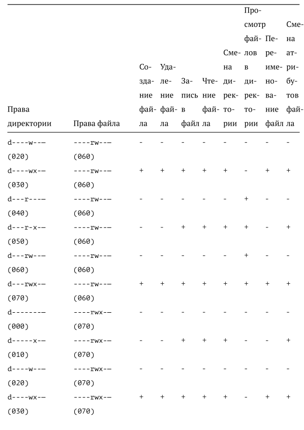

Таблица 3.1

## Заполнение таблицы 3.1

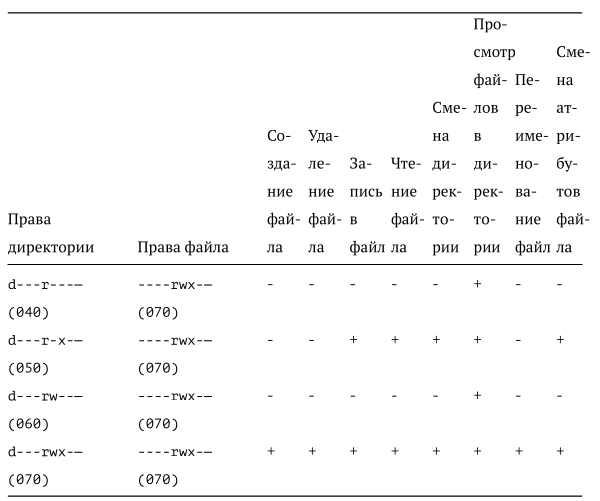

Таблица 3.1

Таблица 3.1 «Установленные права и разрешённые действия для групп»

## Заполнение таблицы 3.2

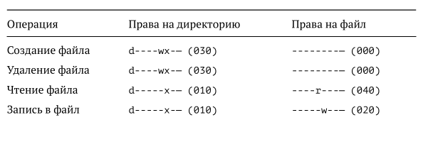

## Заполнение таблицы 3.2

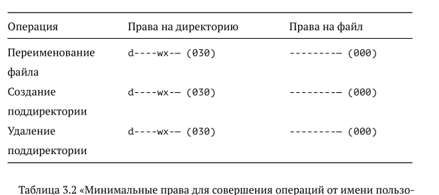

## Заполнение таблицы 3.2

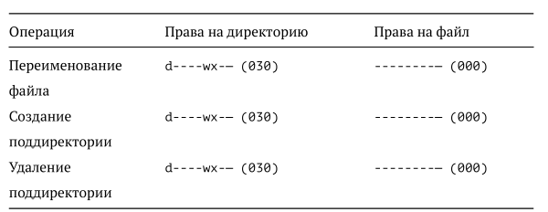

Таблица 3.2

Таблица 3.2 «Минимальные права для совершения операций от имени пользователей входящих в группу»

## Выводы

В ходе данной лабораторной работы я приобрёл практические навыки работы в консоли с атрибутами файлов для групп пользователей.